# Prediction of Exercise Class

RH

Friday, December 11th, 2015

## Loading and cleaning the data

```r
library(caret) #Loads CARET for the machine learning functions
```

```r
#Download and read the training data,
con = url("http://d396qusza40orc.cloudfront.net/predmachlearn/pml-training.csv")
training = read.csv(con)

#Download and read the testing data,
con = url("https://d396qusza40orc.cloudfront.net/predmachlearn/pml-testing.csv")
testing = read.csv(con)
```

Check to see which, if any, columns contain all NAs, and what % of those are NA,

```r
nas = data.frame(sort(colSums(is.na(training))/length(training$classe)*100, decreasing = TRUE)) #Calculate %
nas[,1] = round(nas[,1],2) #Round the answers to 2 decimal places
nas$Names = rownames(nas)
colnames(nas) = c("Percentage NAs", "Variables") #Rename columns
table(nas[,1]) #Generate a table of the percentages
```

```
##
##     0 97.93
##    93    67
```

The above table shows that 67 columns have ~98% NA and 93 are complete. The following variables are the ones with NAs,

```r
nas[nas[,1] !=0,2] #Show which have NAs
```

```
##  [1] "max_roll_belt"            "max_picth_belt"
##  [3] "min_roll_belt"            "min_pitch_belt"
##  [5] "amplitude_roll_belt"      "amplitude_pitch_belt"
##  [7] "var_total_accel_belt"     "avg_roll_belt"
##  [9] "stddev_roll_belt"         "var_roll_belt"
## [11] "avg_pitch_belt"           "stddev_pitch_belt"
## [13] "var_pitch_belt"           "avg_yaw_belt"
## [15] "stddev_yaw_belt"          "var_yaw_belt"
## [17] "var_accel_arm"            "avg_roll_arm"
## [19] "stddev_roll_arm"          "var_roll_arm"
## [21] "avg_pitch_arm"            "stddev_pitch_arm"
## [23] "var_pitch_arm"            "avg_yaw_arm"
## [25] "stddev_yaw_arm"           "var_yaw_arm"
## [27] "max_roll_arm"             "max_picth_arm"
## [29] "max_yaw_arm"              "min_roll_arm"
```

[output cut: 19 more lines]

As the percentages are close to 100%, these variables will be deleted (rather than, say, trying to impute the values which may have a chance of success with a far lower percentage of NAs). The same columns are deleted from the testing data,

```r
#Delete the rows from the training data that have some NAs,
training_na = training[colSums(is.na(training)) == 0]

#Delete the same columns from the testing data,
testing_na = testing[colSums(is.na(training)) == 0]
```

Exploring the data further using ‘str’ revealed many rows containing the text ‘#DIV/0!’. These are shown below,

```r
sort(colSums(training_na == "#DIV/0!"), decreasing = TRUE) #Which contain '#DIV/0!'?
```

```
##       kurtosis_yaw_belt       skewness_yaw_belt   kurtosis_yaw_dumbbell
##                     406                     406                     406
##   skewness_yaw_dumbbell    kurtosis_yaw_forearm    skewness_yaw_forearm
##                     406                     406                     406
##  kurtosis_picth_forearm  skewness_pitch_forearm   kurtosis_roll_forearm
##                      85                      85                      84
##         max_yaw_forearm         min_yaw_forearm   amplitude_yaw_forearm
##                      84                      84                      84
##   skewness_roll_forearm      kurtosis_picth_arm      skewness_pitch_arm
##                      83                      80                      80
##       kurtosis_roll_arm       skewness_roll_arm     kurtosis_picth_belt
##                      78                      77                      32
##    skewness_roll_belt.1        kurtosis_yaw_arm        skewness_yaw_arm
##                      32                      11                      11
##      kurtosis_roll_belt            max_yaw_belt            min_yaw_belt
##                      10                      10                      10
##      amplitude_yaw_belt      skewness_roll_belt  kurtosis_roll_dumbbell
##                      10                       9                       5
##        max_yaw_dumbbell        min_yaw_dumbbell  amplitude_yaw_dumbbell
##                       5                       5                       5
##  skewness_roll_dumbbell kurtosis_picth_dumbbell skewness_pitch_dumbbell
##                       4                       2                       1
##                       X               user_name    raw_timestamp_part_1
##                       0                       0                       0
##    raw_timestamp_part_2          cvtd_timestamp              new_window
##                       0                       0                       0
##              num_window               roll_belt              pitch_belt
##                       0                       0                       0
##                yaw_belt        total_accel_belt            gyros_belt_x
##                       0                       0                       0
##            gyros_belt_y            gyros_belt_z            accel_belt_x
##                       0                       0                       0
##            accel_belt_y            accel_belt_z           magnet_belt_x
##                       0                       0                       0
##           magnet_belt_y           magnet_belt_z                roll_arm
##                       0                       0                       0
##               pitch_arm                 yaw_arm         total_accel_arm
##                       0                       0                       0
##             gyros_arm_x             gyros_arm_y             gyros_arm_z
##                       0                       0                       0
##             accel_arm_x             accel_arm_y             accel_arm_z
##                       0                       0                       0
##            magnet_arm_x            magnet_arm_y            magnet_arm_z
##                       0                       0                       0
##           roll_dumbbell          pitch_dumbbell            yaw_dumbbell
##                       0                       0                       0
##    total_accel_dumbbell        gyros_dumbbell_x        gyros_dumbbell_y
##                       0                       0                       0
##        gyros_dumbbell_z        accel_dumbbell_x        accel_dumbbell_y
##                       0                       0                       0
##        accel_dumbbell_z       magnet_dumbbell_x       magnet_dumbbell_y
##                       0                       0                       0
##       magnet_dumbbell_z            roll_forearm           pitch_forearm
##                       0                       0                       0
##             yaw_forearm     total_accel_forearm         gyros_forearm_x
##                       0                       0                       0
##         gyros_forearm_y         gyros_forearm_z         accel_forearm_x
##                       0                       0                       0
##         accel_forearm_y         accel_forearm_z        magnet_forearm_x
##                       0                       0                       0
##        magnet_forearm_y        magnet_forearm_z                  classe
##                       0                       0                       0
```

These numbers of rows are tiny compared to the total number of rows in the training data. Therefore, deleting the columns would be extremely wasteful. Instead, the individual rows are deleted,

```r
#Create a dataframe containing the row numbers containing #DIV/0!,
divs = data.frame(sort(colSums(training_na == "#DIV/0!"), decreasing = TRUE))

ex = divs[divs[,1] != 0,]

#Create a while loop that goes through each column, adding the row numbers that need deleting to a vector, then deleting these rows,
x=1
while (x<94){
        exc.Numbers = training_na[,x] == "#DIV/0!"
        training_na = training_na[!exc.Numbers, ]
        x=x+1
}

#Drop the factor levels still associated with #DIV/0!,
training_na = droplevels(training_na)
```

Next, see which of the remaining variables have near zero variation (which indicated poor predictive power), and remove them,

```r
training_na_sub = training_na[-nearZeroVar(training_na)]
testing_na_sub = testing_na[-nearZeroVar(training_na)]
```

Looking at the remaining variables, ‘X’ appears be nothing more than a simple sequence of intergers. Therefore, it is removed.  
The variables ‘raw_timestamp_part_1’ and ‘raw_timestamp_part_2’ also appear to be completely uncorrelated with class. They’re removed, too. The plot below shows ‘raw_timestamp_part_2’ vs ‘class’ as an example,

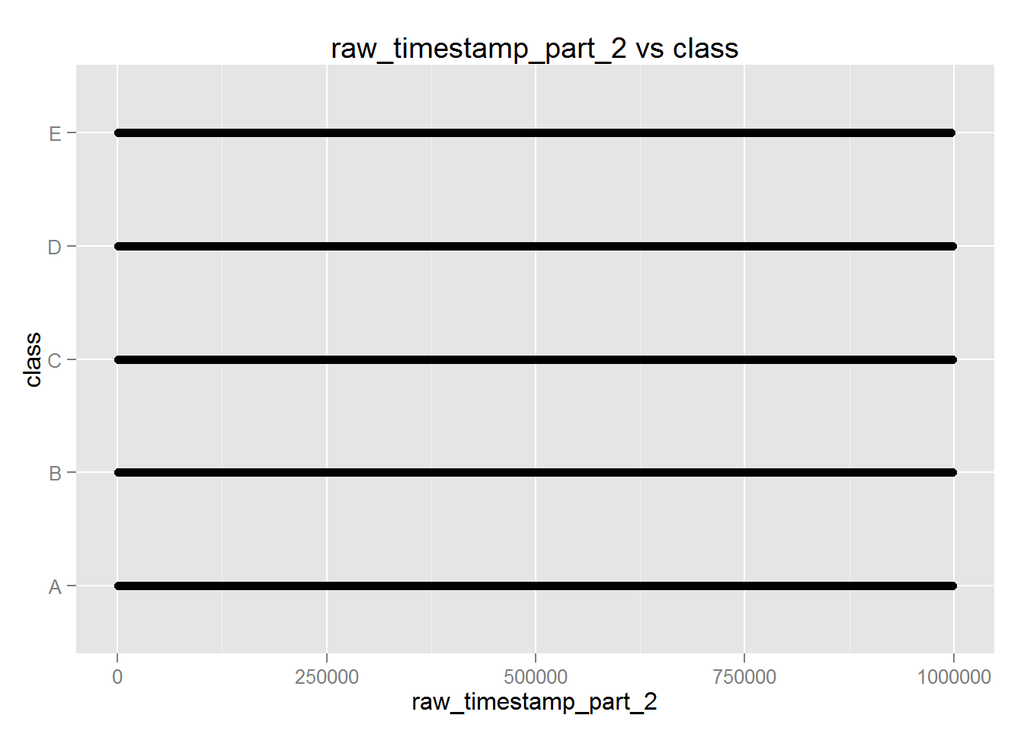

```r
qplot(training_na_sub$raw_timestamp_part_2, training_na_sub$class,
      main = "raw_timestamp_part_2 vs class", xlab = "raw_timestamp_part_2", ylab = "class")
```

```r
#Remove the remaining unrequired columns,
training_na_sub$raw_timestamp_part_1 = NULL
training_na_sub$raw_timestamp_part_2 = NULL
training_na_sub$X = NULL
```

The time variable does not need converting into a time format as it only has 20 levels as a factor. These should offer predictive power as they are,

```r
str(training_na_sub$cvtd_timestamp)
```

```
##  Factor w/ 20 levels "02/12/2011 13:32",..: 9 9 9 9 9 9 9 9 9 9 ...
```

## Model fitting

The resulting training dataset is then fitted using random forests. A ‘leave group out cross validation’ of 25% is used, with 5 repeats,

```r
#Cache the model fit, as it takes quite a while to run
set.seed(100) #Set seed to ensure reproducible results
fitControl <- trainControl(method = "LGOCV", p=0.25, repeats = 5)

model = train(classe ~ ., data = training_na_sub,
              method = "rf",
              trControl = fitControl,
              metric = "Accuracy")
```

The interval CV performance is show using the code below,

```r
getTrainPerf(model) #Internal CV performance
```

```
##   TrainAccuracy TrainKappa method
## 1     0.9914538  0.9891873     rf
```

The variable importance from the model is shown in the plot below,

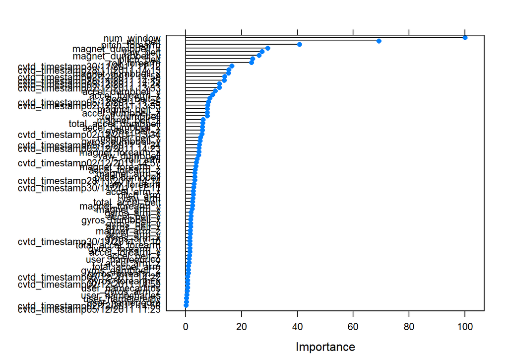

```r
plot(varImp(model))
```

Predicting the 20 test cases gives,

```r
pred1 = predict(model, testing_na_sub)
pred1
```

```
##  [1] B A B A A E D B A A B C B A E E A B B B
## Levels: A B C D E
```

## Out of sample error

The CV is shown in the model performance above (accuracy of 0.991). What about the error from a genuine blind test set? Below the training data is split to a training and test set 70/30. The random forest is then applied to the new, smaller training set and the new test set predicted. Finally, these predictions are compred to the actual class in the test set using a confusion matrix,

```r
#Cache the model fit, as it takes quite a while to run
trainIndex = createDataPartition(training_na_sub$classe, p = 0.7, list = FALSE, times = 1)
training_new = training_na_sub[ trainIndex,]
testing_new = training_na_sub[-trainIndex,]

set.seed(100) #Set seed to ensure reproducible results
fitControl <- trainControl(method = "LGOCV", p=0.25, repeats = 5)

model_sub = train(classe ~ ., data = training_new,
              method = "rf",
              trControl = fitControl,
              metric = "Accuracy")

pred2 = predict(model_sub, testing_new)
confusionMatrix(pred2, testing_new$classe)
```

```
## Confusion Matrix and Statistics
##
##           Reference
## Prediction    A    B    C    D    E
##          A 1641    1    0    0    0
##          B    0 1111    0    0    0
##          C    0    3 1005    1    0
##          D    0    0    0  941    0
##          E    0    0    0    2 1058
##
## Overall Statistics
##
##                Accuracy : 0.9988
##                  95% CI : (0.9975, 0.9995)
##     No Information Rate : 0.2847
##     P-Value [Acc > NIR] : < 2.2e-16
##
##                   Kappa : 0.9985
##  Mcnemar's Test P-Value : NA
##
## Statistics by Class:
##
##                      Class: A Class: B Class: C Class: D Class: E
## Sensitivity            1.0000   0.9964   1.0000   0.9968   1.0000
## Specificity            0.9998   1.0000   0.9992   1.0000   0.9996
## Pos Pred Value         0.9994   1.0000   0.9960   1.0000   0.9981
## Neg Pred Value         1.0000   0.9991   1.0000   0.9994   1.0000
## Prevalence             0.2847   0.1935   0.1744   0.1638   0.1836
## Detection Rate         0.2847   0.1928   0.1744   0.1633   0.1836
## Detection Prevalence   0.2849   0.1928   0.1751   0.1633   0.1839
## Balanced Accuracy      0.9999   0.9982   0.9996   0.9984   0.9998
```

This gives an accuracy of 0.998, which is a fraction better than the internal CV. It also shows a sensitivity and specificity of 1 or nearly 1 for each of the 5 classes.